# Open Science. Guiding Principles and Best Practices

Eberhard Karls Universität Tübingen - Sommersemester 2021

Giorgi Gogilashvili

2021-07-30

### Q1: According to the [Open Definition](https://opendefinition.org/), ‘open’ means anyone can freely access, use, modify, and share for any purpose. The Open Definition was initially derived from the Open Source Definition, which in turn was derived from the original Debian Free Software Guidelines. Richard Stallman was the first to push the ideals of software freedom. List the 4 essential freedoms, as published by the [Free Software Foundation](https://www.gnu.org/philosophy/free-sw.html).

- Freedom 0: “The freedom to run the program as you wish, for any purpose”
- Freedom 1: “The freedom to study how the program works, and change it so it does your computing as you wish.”
- Freedom 2: “The freedom to redistribute copies so you can help others.”
- Freedom 3: “The freedom to distribute copies of your modified versions to others.”

### Q2: “Open Science is the practice of science in such a way that others can collaborate and contribute, where research data, lab notes and other research processes are freely available, under terms that enable reuse, redistribution and reproduction of the research and its underlying data and methods” ([FOSTER Open Science Definition](https://www.fosteropenscience.eu/foster-taxonomy/open-science-definition)). List the 4 foundamental rules of Open Science.

- Open Science is transparent, allowing it to be properly reproducible.
- Open Science is available and free.
- Open Science is accessible.
- Open Science is reusable.

### Q3: The basic principles of Open Science are listed below. Provide for each one a short description.

- Open Data: Data that is transparent, generated through reproducible analysis, and shared with others to facilitate data reuse and accelerated discovery.
- Open Source: The use of open-source software and open formats to conduct scientific data collection, analysis, and presentation, eliminating proprietary/commercial software/formats as a barrier to the accessibility, reproducibility, and reusability of research.
- Open Methods: The development and use of open standards for data collection and metadata, allowing for “easier interpretation and decision-making scrutiny.”
- Open Access: Facilitating the accessibility of knowledge generated by research to anyone interested in it.
- Open Peer Review: The use of a transparent peer review process, increasing accountability on the part of reviewers and making available the actual reviews alongside the published product.
- Open Resources: The increased availability of materials conducive to engaging in Open Science.

### Q4: Open Science leads to increased transparency for greater efficiency, rigour, accountability, sustainability for future generations, and reproducibility. List and describe some of the biases that can be introduced throughout the research process.

Some of the ways that bias can be introduced throughout the research process include research misconduct (involving such things as “making up data or results, selective reporting, cherry picking”), statistical reporting errors, and publication bias (i.e., bias resulting from tendencies on the part of publishers, such as a preference for publishing positive results). Another, more nuanced source of bias is HARKing, or “Hypothesizing After the Results are Known,” which involves retroactively fitting one’s hypothesis to the collected data rather than actually testing a hypothesis.

### Q5: “Open Science is an umbrella term that encompasses a multitude of assumptions about the future of knowledge creation and dissemination”. [Fecher & Friesike 2013](http://dx.doi.org/10.2139/ssrn.2272036) proposed 5 Open Science schools of thought. With which one do you agree the most, and why?

In light of the harm caused by misinformation surrounding the pandemic, I would have to say that the Public School of Open Science is the one that should be pursued most urgently. It is important to make science understandable to laypeople so that they can make well-informed decisions rather than decisions informed by whatever blogs or opinion pieces they happen to come across online. Even those who seek out relatively reliable scientific sources have expressed their confusion at a perceived lack of consensus over how one should act to protect oneself from the virus. In this case, for the sake of public health, it is necessary to make science truly accessible to the public, not only by making the research results openly available but also by providing resources through which they can learn how to sift through and navigate this abundance of data and expert opinions.

### Q6: “Open research data is data that can be freely accessed, reused, remixed and redistributed, for academic research and teaching purposes and beyond” ([The Open Science Training Handbook](https://book.fosteropenscience.eu/en/)). In other terms, open data should comply with the FAIR principles ([Wilkinson et al. 2016](https://doi.org/10.1038/sdata.2016.18)). List and describe the FAIR principles.

- F: Findable - Data should be findable, as finding it is a prerequisite to actually using/reusing it. This can be facilitated through the use of thorough metadata.
- A: Accessible - (Meta)data should be retrievable using a standardized and open communications protocol.
- I: Interoperable - One should be able to combine and use the data with other data and tools. An open data format should be used to allow for this.
- R: Reusable - Data and metadata should be properly described to allow for their reuse. The license(s) that apply to the data should be clear and easily accessible so that those wishing to reuse it can find out under what terms they can do so.

### Q7: “In order to make findings/studies replicable, or at least reproducible or reusable in any other way, the best practice recommendation for research data is to be as open and FAIR as possible, while accounting for ethical, commercial and privacy constraints with sensitive data or proprietary data” ([The Open Science Training Handbook](https://book.fosteropenscience.eu/en/)). List and comment at least a technical and a legal solution to FAIRly share and reuse sensitive data and/or to protect the Intellectual Property (IP).

- Legal solution: One can share personal data through “a combination of obtaining informed consent, data anonymisation and regulating data access.”
- Technical solution: One can “[redact] portions of data to protect intellectual property.”

### Q8: More and more research funders expect the research data produced in the projects they founded to be findable, accessible and as open as possible. In deciding where to archive and/or publish your data, you may have a number of choises. In order of preference, what is the 1st recommendation from [OpenAIRE](https://www.openaire.eu/opendatapilot-repository-guide)?

1. “Use an external data archive or repository already established for your research domain to preserve the data according to recognised standards in your discipline.”

### Q9: “An article about a computational result is advertising, not scholarship. The actual scholarship is the full software environment, code and data, that produced the result” ([Buckheit & Donoho 1995](https://doi.org/10.1007/978-1-4612-2544-7_5)). Reproducibility is at the core of the scientific method. It leads to increased rigour and quality in the research. What are the advantages of working reproducibly for an individual researcher?

Some of the advantages of working reproducibly for the researcher are the opportunity to receive feedback on one’s work more quickly and more often, the potential for finding collaborators, and greater publicity for the researcher’s work.

### Q10: What is a research compendium? Provide a definition and a link to an example.

“A research compendium is a collection of all digital parts of a research project, including data, code, texts.” “A research compendium can be constructed with minimal technical knowledge (a basic folder structure combining all components can be sufficient).” “Publishing your research paper along with a research compendium allows others to access your input, test your analysis, and, if the compendium can be executed, rerun to assess the resulting output. This does not only instill trust in your research but can give you more visibility.”

Link to an example: https://github.com/benmarwick/mjbtramp

### Q11: Preprint, postprint and version of record. What are we talking about? Give a short definition of these terms.

- Preprint: The version of the scholarly work before submission for publication.
- Postprint: The version of the scholarly work accepted for publication.
- Version of record: The published version of the scholarly work.

### Q12: The [Budapest Open Access Initiative](https://www.budapestopenaccessinitiative.org/) defines Open Access (OA) as: “the world-wide electronic distribution of the peer-reviewed journal literature and completely free and unrestricted access to it by all scientists, scholars, teachers, students, and other curious minds”. To achieve OA to scholarly journal literature, The BOAI recommend two complementary strategies: 1) Self-Archiving; 2) Open Access Journals. Check [Sherpa Romeo](https://v2.sherpa.ac.uk/romeo/) to see what are the policies of the Journal of Archaeological Science publisher for self-archiving a postprint. Describe pathways a) and b).

1. Requires an Open Access fee; does not include an embargo; uses the BY-NC-ND 4.0 Creative Commons license; publishing takes place on a specified repository, non-commercial repository, or a journal website. The published source must be acknowledged with a citation.
2. Requires an Open Access fee; does not include an embargo; uses the BY Creative Commons license (one only needs to provide proper attritution of the work to reuse it); publication takes place on a institutional, specified, or non-commercial repository or a journal website. The published source must be acknowledged with a citation.

### Q13: Now check [Sherpa Juliet](https://v2.sherpa.ac.uk/juliet/) to see when and where the European Research Council (ERC) requires Open Access Archiving. Report the ERC policy.

The ERC requires the Open Access archiving of peer-reviewed publications and other, unspecified documents in both the publisher’s and author’s final versions. These need to be archived as early as possible, with a possible embargo of 6 months. Archiving may take place on: the author’s own website; an appropriate institutional repository; an appropriate national repository; an appropriate disciplinary repository; any appropriate repository; or the following named repositories: Europe PMC (http://europepmc.org/); ArXiv (http://arxiv.org/).

### Q14: “Public domain” is a technical term in copyright law that refers to works not under copyright — either because they were never in copyright to begin with […], or because their copyright term has finally lapsed and they have “fallen into” the public domain. […] Not all jurisdictions have a public domain, and it doesn’t always mean exactly the same thing in the jurisdictions that do have it. Furthermore, even where it is clear what it means, it’s still not a license. To be subject to a license, a work must still be in copyright ([Open Source Initiative](https://opensource.org/faq#osd)). The [CC0](https://creativecommons.org/share-your-work/public-domain/cc0/) license can be used as an “effective” public domain license that allows unrestricted use. For what the CC0 was originally created?

The CC0 license was created so that authors could waive their copyright over their work, thus giving them the ability to release their work into the public domain whenever they wish rather than having to wait for the copyright term applying to the work to lapse.

### Q15: Open Peer Review has been described as “an umbrella term for a number of overlapping ways that peer review models can be adapted in line with the aims of Open Science” ([Ross-Hellauer 2017](https://doi.org/10/gc5sjh)). What are the main and the optional traits of Open Peer Review?

Main traits:

- Open identities: Both the authors and the reviewers know each other’s identities.
- Open reports: Review reports are published alongside the associated article.

Optional traits:

- Open participation: “members of the wider community are able to contribute to the review process”
- Open interaction: “direct reciprocal discussion between author(s) and reviewers, and/or between reviewers, is allowed and encouraged”
- Open pre-review manuscripts: “manuscripts are made immediately available in advance of any formal peer review procedures”
- Open final-version commenting: “Review or commenting on final ‘version of record’ publications.”
- Open platforms (“decoupled review”): “Review is facilitated by a different organizational entity than the venue of publication.”

### Q16: The `Olorgesailie.maj` dataset, included in the `archdata` package, represent the number of specimens in each of 6 major artifact classes recovered from 19 localities at the Lower Paleolithic site of Olorgesailie as described in Isaac (1977). By using the `ggplot2` package, plot the total amount of large cutting tools per localities. Which locality yielded more large cutting tools?

```r
# install and load the `tidyverse` package

# install and load the `archdata` package

# load the `Olorgesailie.maj` dataset

# print the structure of the dataset

# print the names of the 19 localities at the Olorgesaille site from where the artifacts were recovered. (Note that the names of the localities are stored as an attribute of the dataset: "row.names")

# bar plot of the total count of large cutting tools (y axis) per localities (x axis)
```

```r
# install and load the `tidyverse` package
install.packages("tidyverse", repos = "https://mirror.lyrahosting.com/CRAN/")
library(tidyverse)
# install and load the `archdata` package
install.packages("archdata", repos = "https://mirror.lyrahosting.com/CRAN/")
library(archdata)
data(package="archdata")

# load the `Olorgesailie.maj` dataset
data("Olorgesailie.maj")

# print the structure of the dataset
str(Olorgesailie.maj)
```

```
## 'data.frame':    19 obs. of  6 variables:
##  $ Large.cutting.tools: int  1 13 6 0 33 51 34 69 435 24 ...
##  $ Heavy.duty.tools   : int  1 9 7 0 14 11 1 7 30 5 ...
##  $ Large.scrapers     : int  0 0 1 0 6 5 3 4 38 3 ...
##  $ Other.large.tools  : int  0 2 6 0 24 6 5 5 20 2 ...
##  $ Small.tools        : int  59 42 34 0 139 124 7 10 50 41 ...
##  $ Spheroids          : int  0 2 0 1 3 1 0 8 8 2 ...
```

```r
# print the names of the 19 localities at the Olorgesaille site from where the artifacts were recovered. (Note that the names of the localities are stored as an attribute of the dataset: "row.names")
row.names(Olorgesailie.maj)
```

```
##  [1] "LS1"  "LS2"  "LS3"  "LS4"  "LS5"  "MS1a" "MS1b" "MS2a" "MS2b" "MS3"
## [11] "MS4"  "MS5"  "MS6"  "MS7"  "MS8"  "MS9"  "US1"  "US2"  "US3"
```

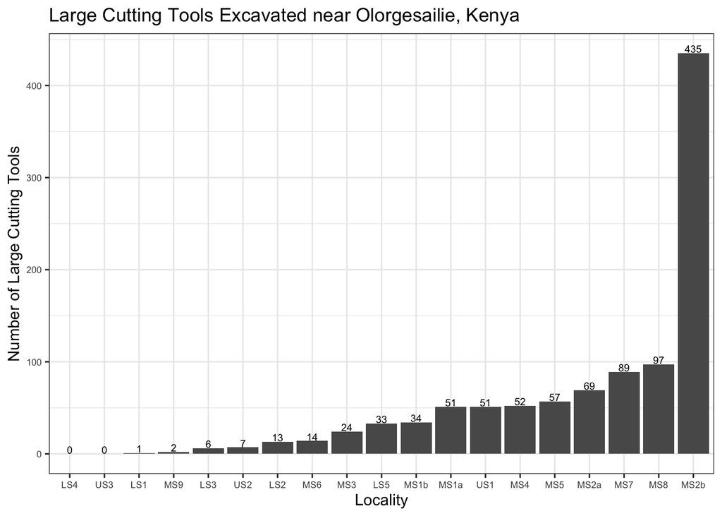

```r
# bar plot of the total count of large cutting tools (y axis) per localities (x axis)
ggplot(Olorgesailie.maj, aes(x=reorder(row.names(Olorgesailie.maj), Large.cutting.tools), y=Large.cutting.tools)) + geom_bar(stat="identity") + labs(title="Large Cutting Tools Excavated near Olorgesailie, Kenya", x="Locality", y="Number of Large Cutting Tools") + geom_text(aes(label=Large.cutting.tools, vjust=-0.1), size=2.5) + theme_bw() + theme(axis.text = element_text(size=6.5))
```